# wrangle_act

```python
import pandas as pd
import json
import requests
import tweepy
from tweepy import OAuthHandler
import os
import matplotlib.pyplot as plt
% matplotlib inline
import seaborn as sns
import re
import sys
import time

from datetime import datetime
from functools import reduce
```

### Gather

```python
#load enhanced twitter archive file
twitter_1 = pd.read_csv('twitter-archive-enhanced.csv')
```

```python
#scrape image predictions file from Udacity website
url = 'https://d17h27t6h515a5.cloudfront.net/topher/2017/August/599fd2ad_image-predictions/image-predictions.tsv'
response = requests.get(url)

with open (os.path.join('image-predictions.tsv'), mode = 'wb') as file:
          file.write(response.content)
```

```python
#load image predictions file
images = pd.read_csv('image-predictions.tsv', sep = '\t')
```

```python
#access the Twitter API using tweepy with OAuth
import tweepy
#consumer keys and access tokens used for OAuth
consumer_key = 'xxxx'
consumer_secret = 'xxxx'
access_token = 'xxxx'
access_secret = 'xxxx'

#OAuth process, using the keys and tokens
auth = tweepy.OAuthHandler(consumer_key, consumer_secret)
auth.set_access_token(access_token, access_secret)

#creation of the actual interface, using authentication
api = tweepy.API(auth_handler=auth, wait_on_rate_limit = True, wait_on_rate_limit_notify = True)
```

```python
#use twitter API to collect status data on tweets
import time
import pandas as pd
df = pd.read_csv('twitter-archive-enhanced.csv')
tweet_data = {}
tweet_errors = {}

for tweet_id in df["tweet_id"]:
    try:
        tweet = api.get_status(tweet_id)
        tweet_data[str(tweet_id)] = tweet._json
        print(tweet_id)
    except Exception as e:

        print(str(tweet_id) + ':' + str(e))
        tweet_errors[tweet_id] = tweet
```

[output not shown]

[output cut: 2304 more lines]

[output not shown]

```python
#write tweet data to json file
import json

with open('tweet_json.txt', 'w') as outfile:
          json.dump(tweet_data, outfile)
          sort_keys = True,
          indent = 4,
          ensure_ascii = False
```

```python
#load JSON data into 'df_tweet2'
df_tweet2 = pd.read_json('tweet_json.txt', orient = 'index')
df_tweet2.head(2)
```

|  | contributors | coordinates | created_at | entities | extended_entities | favorite_count | favorited | geo | id | id_str | ... | quoted_status | quoted_status_id | quoted_status_id_str | retweet_count | retweeted | retweeted_status | source | text | truncated | user |
| --- | --- | --- | --- | --- | --- | --- | --- | --- | --- | --- | --- | --- | --- | --- | --- | --- | --- | --- | --- | --- | --- |
| 1998-04-12 22:37:23.555336193 | NaN | NaN | 2017-08-01 16:23:56 | {'hashtags': [], 'symbols': [], 'user_mentions... | {'media': [{'id': 892420639486877696, 'id_str'... | 37113 | 0 | NaN | 892420643555336192 | 892420643555336192 | ... | NaN | NaN | NaN | 7929 | 0 | NaN | <a href="http://twitter.com/download/iphone" r... | This is Phineas. He's a mystical boy. Only eve... | 0 | {'id': 4196983835, 'id_str': '4196983835', 'na... |
| 1998-04-10 03:03:41.306343426 | NaN | NaN | 2017-08-01 00:17:27 | {'hashtags': [], 'symbols': [], 'user_mentions... | NaN | 31933 | 0 | NaN | 892177421306343424 | 892177421306343424 | ... | NaN | NaN | NaN | 5890 | 0 | NaN | <a href="http://twitter.com/download/iphone" r... | This is Tilly. She's just checking pup on you.... | 1 | {'id': 4196983835, 'id_str': '4196983835', 'na... |

2 rows × 30 columns

```python
#creates new df for tweet_json
df_tweet2 = pd.read_json('tweet_json.txt', orient = 'index')

#subset columns
df_count = ['id', 'retweet_count', 'favorite_count']
df_tweet2 = df_tweet2[df_count]

#rename column 'id' to 'tweet_id'
df_tweet2.rename(columns={'id':'tweet_id'}, inplace = True)
```

### Assess

```python
twitter_1.info()
```

```
<class 'pandas.core.frame.DataFrame'>
RangeIndex: 2356 entries, 0 to 2355
Data columns (total 17 columns):
tweet_id                      2356 non-null int64
in_reply_to_status_id         78 non-null float64
in_reply_to_user_id           78 non-null float64
timestamp                     2356 non-null object
source                        2356 non-null object
text                          2356 non-null object
retweeted_status_id           181 non-null float64
retweeted_status_user_id      181 non-null float64
retweeted_status_timestamp    181 non-null object
expanded_urls                 2297 non-null object
rating_numerator              2356 non-null int64
rating_denominator            2356 non-null int64
name                          2356 non-null object
doggo                         2356 non-null object
floofer                       2356 non-null object
pupper                        2356 non-null object
puppo                         2356 non-null object
dtypes: float64(4), int64(3), object(10)
memory usage: 313.0+ KB
```

```python
twitter_1.head()
```

|  | tweet_id | in_reply_to_status_id | in_reply_to_user_id | timestamp | source | text | retweeted_status_id | retweeted_status_user_id | retweeted_status_timestamp | expanded_urls | rating_numerator | rating_denominator | name | doggo | floofer | pupper | puppo |
| --- | --- | --- | --- | --- | --- | --- | --- | --- | --- | --- | --- | --- | --- | --- | --- | --- | --- |
| 0 | 892420643555336193 | NaN | NaN | 2017-08-01 16:23:56 +0000 | <a href="http://twitter.com/download/iphone" r... | This is Phineas. He's a mystical boy. Only eve... | NaN | NaN | NaN | https://twitter.com/dog_rates/status/892420643... | 13 | 10 | Phineas | None | None | None | None |
| 1 | 892177421306343426 | NaN | NaN | 2017-08-01 00:17:27 +0000 | <a href="http://twitter.com/download/iphone" r... | This is Tilly. She's just checking pup on you.... | NaN | NaN | NaN | https://twitter.com/dog_rates/status/892177421... | 13 | 10 | Tilly | None | None | None | None |
| 2 | 891815181378084864 | NaN | NaN | 2017-07-31 00:18:03 +0000 | <a href="http://twitter.com/download/iphone" r... | This is Archie. He is a rare Norwegian Pouncin... | NaN | NaN | NaN | https://twitter.com/dog_rates/status/891815181... | 12 | 10 | Archie | None | None | None | None |
| 3 | 891689557279858688 | NaN | NaN | 2017-07-30 15:58:51 +0000 | <a href="http://twitter.com/download/iphone" r... | This is Darla. She commenced a snooze mid meal... | NaN | NaN | NaN | https://twitter.com/dog_rates/status/891689557... | 13 | 10 | Darla | None | None | None | None |
| 4 | 891327558926688256 | NaN | NaN | 2017-07-29 16:00:24 +0000 | <a href="http://twitter.com/download/iphone" r... | This is Franklin. He would like you to stop ca... | NaN | NaN | NaN | https://twitter.com/dog_rates/status/891327558... | 12 | 10 | Franklin | None | None | None | None |

```python
twitter_1.tail()
```

|  | tweet_id | in_reply_to_status_id | in_reply_to_user_id | timestamp | source | text | retweeted_status_id | retweeted_status_user_id | retweeted_status_timestamp | expanded_urls | rating_numerator | rating_denominator | name | doggo | floofer | pupper | puppo |
| --- | --- | --- | --- | --- | --- | --- | --- | --- | --- | --- | --- | --- | --- | --- | --- | --- | --- |
| 2351 | 666049248165822465 | NaN | NaN | 2015-11-16 00:24:50 +0000 | <a href="http://twitter.com/download/iphone" r... | Here we have a 1949 1st generation vulpix. Enj... | NaN | NaN | NaN | https://twitter.com/dog_rates/status/666049248... | 5 | 10 | None | None | None | None | None |
| 2352 | 666044226329800704 | NaN | NaN | 2015-11-16 00:04:52 +0000 | <a href="http://twitter.com/download/iphone" r... | This is a purebred Piers Morgan. Loves to Netf... | NaN | NaN | NaN | https://twitter.com/dog_rates/status/666044226... | 6 | 10 | a | None | None | None | None |
| 2353 | 666033412701032449 | NaN | NaN | 2015-11-15 23:21:54 +0000 | <a href="http://twitter.com/download/iphone" r... | Here is a very happy pup. Big fan of well-main... | NaN | NaN | NaN | https://twitter.com/dog_rates/status/666033412... | 9 | 10 | a | None | None | None | None |
| 2354 | 666029285002620928 | NaN | NaN | 2015-11-15 23:05:30 +0000 | <a href="http://twitter.com/download/iphone" r... | This is a western brown Mitsubishi terrier. Up... | NaN | NaN | NaN | https://twitter.com/dog_rates/status/666029285... | 7 | 10 | a | None | None | None | None |
| 2355 | 666020888022790149 | NaN | NaN | 2015-11-15 22:32:08 +0000 | <a href="http://twitter.com/download/iphone" r... | Here we have a Japanese Irish Setter. Lost eye... | NaN | NaN | NaN | https://twitter.com/dog_rates/status/666020888... | 8 | 10 | None | None | None | None | None |

```python
twitter_1.sample(3)
```

|  | tweet_id | in_reply_to_status_id | in_reply_to_user_id | timestamp | source | text | retweeted_status_id | retweeted_status_user_id | retweeted_status_timestamp | expanded_urls | rating_numerator | rating_denominator | name | doggo | floofer | pupper | puppo |
| --- | --- | --- | --- | --- | --- | --- | --- | --- | --- | --- | --- | --- | --- | --- | --- | --- | --- |
| 452 | 818614493328580609 | NaN | NaN | 2017-01-10 00:24:38 +0000 | <a href="http://twitter.com/download/iphone" r... | This is Bear. He's a passionate believer of th... | NaN | NaN | NaN | https://twitter.com/dog_rates/status/818614493... | 12 | 10 | Bear | None | None | None | None |
| 745 | 780092040432480260 | NaN | NaN | 2016-09-25 17:10:10 +0000 | <a href="http://twitter.com/download/iphone" r... | RT @dog_rates: This is Hank. He's mischievous ... | 7.533757e+17 | 4.196984e+09 | 2016-07-13 23:48:51 +0000 | https://twitter.com/dog_rates/status/753375668... | 8 | 10 | Hank | None | None | None | None |
| 1574 | 687480748861947905 | NaN | NaN | 2016-01-14 03:45:57 +0000 | <a href="http://twitter.com/download/iphone" r... | Another magnificent photo. 12/10 https://t.co/... | NaN | NaN | NaN | https://twitter.com/dog_rates/status/687480748... | 12 | 10 | None | None | None | None | None |

```python
twitter_1.describe()
```

|  | tweet_id | in_reply_to_status_id | in_reply_to_user_id | retweeted_status_id | retweeted_status_user_id | rating_numerator | rating_denominator |
| --- | --- | --- | --- | --- | --- | --- | --- |
| count | 2.356000e+03 | 7.800000e+01 | 7.800000e+01 | 1.810000e+02 | 1.810000e+02 | 2356.000000 | 2356.000000 |
| mean | 7.427716e+17 | 7.455079e+17 | 2.014171e+16 | 7.720400e+17 | 1.241698e+16 | 13.126486 | 10.455433 |
| std | 6.856705e+16 | 7.582492e+16 | 1.252797e+17 | 6.236928e+16 | 9.599254e+16 | 45.876648 | 6.745237 |
| min | 6.660209e+17 | 6.658147e+17 | 1.185634e+07 | 6.661041e+17 | 7.832140e+05 | 0.000000 | 0.000000 |
| 25% | 6.783989e+17 | 6.757419e+17 | 3.086374e+08 | 7.186315e+17 | 4.196984e+09 | 10.000000 | 10.000000 |
| 50% | 7.196279e+17 | 7.038708e+17 | 4.196984e+09 | 7.804657e+17 | 4.196984e+09 | 11.000000 | 10.000000 |
| 75% | 7.993373e+17 | 8.257804e+17 | 4.196984e+09 | 8.203146e+17 | 4.196984e+09 | 12.000000 | 10.000000 |
| max | 8.924206e+17 | 8.862664e+17 | 8.405479e+17 | 8.874740e+17 | 7.874618e+17 | 1776.000000 | 170.000000 |

```python
twitter_1['tweet_id'].value_counts()
```

```
749075273010798592    1
741099773336379392    1
798644042770751489    1
825120256414846976    1
769212283578875904    1
700462010979500032    1
780858289093574656    1
699775878809702401    1
880095782870896641    1
760521673607086080    1
776477788987613185    1
691820333922455552    1
715696743237730304    1
714606013974974464    1
760539183865880579    1
```

[output cut: 47 more lines]

```python
twitter_1['timestamp'].value_counts()
```

[output not shown]

```python
twitter_1['source'].value_counts()
```

```
<a href="http://twitter.com/download/iphone" rel="nofollow">Twitter for iPhone</a>     2221
<a href="http://vine.co" rel="nofollow">Vine - Make a Scene</a>                          91
<a href="http://twitter.com" rel="nofollow">Twitter Web Client</a>                       33
<a href="https://about.twitter.com/products/tweetdeck" rel="nofollow">TweetDeck</a>      11
Name: source, dtype: int64
```

```python
twitter_1['text'].value_counts()
```

```
This is Julio. He was one of the original Ringling Bros. Exceptional balance. Very alert. Ready for anything. 10/10 https://t.co/aeURGO9Qs8                             1
This is Neptune. He's a Snowy Swiss Mountain Floofapolis. Cheeky wink. Tongue nifty af. 11/10 would pet so firmly https://t.co/SoZq2Xoopv                               1
RT @dog_rates: This is Sunny. She was also a very good First Doggo. 14/10 would also be an absolute honor to pet https://t.co/YOC1fHFCSb                                1
This is Jaspers. He is a northeastern Gillette. Just got his license. Very excited. 10/10 they grow up so fast https://t.co/cieaOI0RuT                                  1
Here we are witnessing an isolated squad of bouncing doggos. Unbelievably rare for this time of year. 11/10 for all https://t.co/CCdlwiTwQf                             1
Here we see really big dog cuddling smaller dog. Very touching. True friendship. 10/10s would pet both at once https://t.co/A6XnvxHiUQ                                  1
Meet Piper. She's an airport doggo. Please return your tray table to its full pupright and locked position. 11/10 https://t.co/D17IAcetmM                               1
This is Ed. He's not mad, just disappointed. 10/10 https://t.co/BIljU0zhLN                                                                                              1
Oh jeez u did me quite the spook little fella. We normally don't rate triceratops but this one seems suspiciously good. 11/10 would pet well https://t.co/BMtfCmNbnS    1
WeRateDogs stickers are here and they're 12/10! Use code "puppers" at checkout 🐶🐾\n\nShop now: https://t.co/k5xsufRKYm https://t.co/ShXk46V13r                          1
When your teacher agreed on 10,000 RTs and no final but after 24 hours you only have 37... 10/10 https://t.co/sVnJfWVjUp                                                1
This is Alice. She's an idiot. 4/10 https://t.co/VQXdwJfkyS                                                                                                             1
This is Claude. He's trying to be seductive but he forgot to turn on the fireplace. 9/10 damn it Claude https://t.co/EPdQquc1dG                                         1
Take all my money. 10/10 https://t.co/B28ebc5LzQ                                                                                                                        1
This is Wallace. You said you brushed your teeth but he checked your toothbrush and it was bone dry. 11/10 not pupset, just disappointed https://t.co/nadm8yWZ4h        1
Meet George. He looks slightly deflated but overall quite powerful. Not sure how that human restrained him. 12/10 would snug with permission https://t.co/o6E0hB3xZl    1
Say hello to Sunny and Roxy. They pull things out of water together. 10/10 for both https://t.co/88aedAmxcl                                                             1
This is Jay. He's really h*ckin happy about the start of fall. Sneaky tongue slip in 2nd pic. 11/10 snuggly af https://t.co/vyx1X5eyWI                                  1
RT @dog_rates: This is Kyro. He's a Stratocumulus Flop. Tongue ejects at random. Serious h*ckin condition. Still 12/10 would pet passionate…                            1
Say hello to Boomer. He's a sandy pupper. Having a h*ckin blast. 12/10 would pet passionately https://t.co/ecb3LvExde                                                   1
This is Albus. He's quite impressive at hide and seek. Knows he's been found this time. 13/10 usually elusive as h*ck https://t.co/ht47njyZ64                           1
Stop what you're doing and watch this heckin masterpiece right here. Both 13/10 https://t.co/3BOVI2WZoH                                                                 1
This is Kyro. He's a Stratocumulus Flop. Tongue ejects at random. Serious h*ckin condition. Still 12/10 would pet passionately https://t.co/wHu15q2Q6p                  1
Have you ever seen such a smol pupper? Portable af. 12/10 would keep in shirt pocket https://t.co/KsqaIzlQ12                                                            1
I know we only rate dogs, but since it's Easter I guess we could rate a bunny for a change. 10/10 petable as hell https://t.co/O2RlKXigHu                               1
This is Tucker. He's a Dasani Episcopalian. Good lord what a tongue. 12/10 would never let go of https://t.co/gHtW5cgyy7                                                1
This is Furzey. He's doing an elevated sandy zoom. Adjusts ears to steer. 12/10 would pet mid flight https://t.co/zhbRIZQgnq                                            1
```

[output cut: 35 more lines]

```python
twitter_1['retweeted_status_id'].value_counts()
```

[output not shown]

```python
twitter_1['retweeted_status_user_id'].value_counts()
```

```
4.196984e+09    156
4.296832e+09      2
5.870972e+07      1
6.669901e+07      1
4.119842e+07      1
7.475543e+17      1
7.832140e+05      1
7.266347e+08      1
4.871977e+08      1
5.970642e+08      1
4.466750e+07      1
1.228326e+09      1
7.992370e+07      1
2.488557e+07      1
7.874618e+17      1
3.638908e+08      1
5.128045e+08      1
8.117408e+08      1
1.732729e+09      1
1.960740e+07      1
1.547674e+08      1
3.410211e+08      1
7.124572e+17      1
2.804798e+08      1
1.950368e+08      1
Name: retweeted_status_user_id, dtype: int64
```

```python
twitter_1['retweeted_status_timestamp'].value_counts()
```

[output not shown]

```python
twitter_1['expanded_urls'].value_counts()
```

```
https://twitter.com/dog_rates/status/780931614150983680/photo/1                                                                                                                                                                                                                                             …
https://www.gofundme.com/helpquinny,https://twitter.com/dog_rates/status/863062471531167744/photo/1,https://twitter.com/dog_rates/status/863062471531167744/photo/1,https://twitter.com/dog_rates/status/863062471531167744/photo/1,https://twitter.com/dog_rates/status/863062471531167744/photo/1         …
https://twitter.com/dog_rates/status/816450570814898180/photo/1,https://twitter.com/dog_rates/status/816450570814898180/photo/1                                                                                                                                                                             …
https://twitter.com/dog_rates/status/782305867769217024/photo/1,https://twitter.com/dog_rates/status/782305867769217024/photo/1,https://twitter.com/dog_rates/status/782305867769217024/photo/1                                                                                                             …
https://twitter.com/dog_rates/status/809920764300447744/photo/1                                                                                                                                                                                                                                             …
https://twitter.com/dog_rates/status/687317306314240000/photo/1,https://twitter.com/dog_rates/status/687317306314240000/photo/1                                                                                                                                                                             …
https://twitter.com/dog_rates/status/700143752053182464/photo/1                                                                                                                                                                                                                                             …
https://www.gofundme.com/help-lorenzo-beat-cancer,https://twitter.com/dog_rates/status/860563773140209665/photo/1,https://twitter.com/dog_rates/status/860563773140209665/photo/1                                                                                                                           …
https://twitter.com/dog_rates/status/667866724293877760/photo/1                                                                                                                                                                                                                                             …
https://twitter.com/dog_rates/status/669000397445533696/photo/1                                                                                                                                                                                                                                             …
https://twitter.com/dog_rates/status/750719632563142656/photo/1                                                                                                                                                                                                                                             …
https://twitter.com/dog_rates/status/673295268553605120/photo/1                                                                                                                                                                                                                                             …
https://twitter.com/dog_rates/status/680055455951884288/photo/1                                                                                                                                                                                                                                             …
https://twitter.com/dog_rates/status/718631497683582976/photo/1                                                                                                                                                                                                                                             …
https://twitter.com/dog_rates/status/837820167694528512/photo/1,https://twitter.com/dog_rates/status/837820167694528512/photo/1                                                                                                                                                                             …
https://twitter.com/dog_rates/status/762464539388485633/photo/1,https://twitter.com/dog_rates/status/762464539388485633/photo/1,https://twitter.com/dog_rates/status/762464539388485633/photo/1,https://twitter.com/dog_rates/status/762464539388485633/photo/1                                             …
http://www.gofundme.com/bluethewhitehusky,https://twitter.com/dog_rates/status/831650051525054464/photo/1,https://twitter.com/dog_rates/status/831650051525054464/photo/1,https://twitter.com/dog_rates/status/831650051525054464/photo/1,https://twitter.com/dog_rates/status/831650051525054464/photo/1   …
https://www.gofundme.com/surgeryforjacktheminpin,https://twitter.com/dog_rates/status/815990720817401858/photo/1                                                                                                                                                                                            …
```

[output cut: 44 more lines]

```python
twitter_1['rating_numerator'].value_counts()
```

```
12      558
11      464
10      461
13      351
9       158
8       102
7        55
14       54
5        37
6        32
3        19
4        17
1         9
2         9
420       2
```

[output cut: 26 more lines]

```python
twitter_1['rating_denominator'].value_counts()
```

```
10     2333
11        3
50        3
80        2
20        2
2         1
16        1
40        1
70        1
15        1
90        1
110       1
120       1
130       1
150       1
170       1
7         1
0         1
Name: rating_denominator, dtype: int64
```

```python
twitter_1['name'].value_counts()
```

```
None         745
a             55
Charlie       12
Oliver        11
Cooper        11
Lucy          11
Penny         10
Lola          10
Tucker        10
Bo             9
Winston        9
Sadie          8
the            8
Daisy          7
Buddy          7
Toby           7
Bailey         7
an             7
Scout          6
Dave           6
Stanley        6
Jax            6
Leo            6
Koda           6
Bella          6
Oscar          6
Milo           6
Rusty          6
Jack           6
Larry          5
            ...
Edd            1
Dido           1
Hanz           1
Heinrich       1
Colin          1
Grizzwald      1
Barney         1
Corey          1
Derby          1
Sailor         1
Rey            1
Comet          1
Noosh          1
Hamrick        1
Tiger          1
Edmund         1
Noah           1
Bones          1
Skittles       1
Andru          1
Mitch          1
Lucia          1
Oddie          1
Beemo          1
Laika          1
Kial           1
Tuck           1
Keet           1
Fiji           1
Rover          1
Name: name, Length: 957, dtype: int64
```

```python
twitter_1['doggo'].value_counts()
```

```
None     2259
doggo      97
Name: doggo, dtype: int64
```

```python
twitter_1['floofer'].value_counts()
```

```
None       2346
floofer      10
Name: floofer, dtype: int64
```

```python
twitter_1['pupper'].value_counts()
```

```
None      2099
pupper     257
Name: pupper, dtype: int64
```

```python
twitter_1['puppo'].value_counts()
```

```
None     2326
puppo      30
Name: puppo, dtype: int64
```

```python
twitter_1.loc[twitter_1['name'].str.isupper()]
```

|  | tweet_id | in_reply_to_status_id | in_reply_to_user_id | timestamp | source | text | retweeted_status_id | retweeted_status_user_id | retweeted_status_timestamp | expanded_urls | rating_numerator | rating_denominator | name | doggo | floofer | pupper | puppo |
| --- | --- | --- | --- | --- | --- | --- | --- | --- | --- | --- | --- | --- | --- | --- | --- | --- | --- |
| 775 | 776201521193218049 | NaN | NaN | 2016-09-14 23:30:38 +0000 | <a href="http://twitter.com/download/iphone" r... | This is O'Malley. That is how he sleeps. Doesn... | NaN | NaN | NaN | https://twitter.com/dog_rates/status/776201521... | 10 | 10 | O | None | None | None | None |
| 2041 | 671542985629241344 | NaN | NaN | 2015-12-01 04:14:59 +0000 | <a href="http://twitter.com/download/iphone" r... | This is JD (stands for "just dog"). He's like ... | NaN | NaN | NaN | https://twitter.com/dog_rates/status/671542985... | 10 | 10 | JD | None | None | None | None |

```python
df_tweet2.head()
```

|  | tweet_id | retweet_count | favorite_count |
| --- | --- | --- | --- |
| 1998-04-12 22:37:23.555336193 | 892420643555336192 | 7929 | 37113 |
| 1998-04-10 03:03:41.306343426 | 892177421306343424 | 5890 | 31933 |
| 1998-04-05 22:26:21.378084864 | 891815181378084864 | 3892 | 24038 |
| 1998-04-04 11:32:37.279858688 | 891689557279858688 | 8087 | 40430 |
| 1998-03-31 06:59:18.926688256 | 891327558926688256 | 8771 | 38660 |

```python
df_tweet2.info()
```

```
<class 'pandas.core.frame.DataFrame'>
DatetimeIndex: 2333 entries, 1998-04-12 22:37:23.555336193 to 1991-02-08 13:48:08.022790149
Data columns (total 3 columns):
tweet_id          2333 non-null int64
retweet_count     2333 non-null int64
favorite_count    2333 non-null int64
dtypes: int64(3)
memory usage: 72.9 KB
```

```python
df_tweet2.describe()
```

|  | tweet_id | retweet_count | favorite_count |
| --- | --- | --- | --- |
| count | 2.333000e+03 | 2333.000000 | 2333.000000 |
| mean | 7.419279e+17 | 2790.802400 | 7739.446207 |
| std | 6.820607e+16 | 4723.898672 | 12014.902046 |
| min | 6.660209e+17 | 1.000000 | 0.000000 |
| 25% | 6.782786e+17 | 560.000000 | 1340.000000 |
| 50% | 7.184547e+17 | 1303.000000 | 3375.000000 |
| 75% | 7.986654e+17 | 3247.000000 | 9498.000000 |
| max | 8.924206e+17 | 80197.000000 | 160359.000000 |

```python
df_tweet2['tweet_id'].value_counts()
```

```
805823200554876928    1
838476387338051584    1
759923798737051648    1
678991772295516160    1
818259473185828864    1
809920764300447744    1
672877615439593472    1
673686845050527744    1
670764103623966720    1
805487436403003392    1
833479644947025920    1
784517518371221504    1
825120256414846976    1
769212283578875904    1
700462010979500032    1
```

[output cut: 47 more lines]

```python
df_tweet2['retweet_count'].value_counts()
```

```
1796     5
55       5
121      5
234      5
982      5
761      4
1951     4
1010     4
510      4
522      4
44       4
570      4
556      4
473      4
574      4
```

[output cut: 47 more lines]

```python
df_tweet2['favorite_count'].value_counts()
```

```
0        165
2491       4
2910       3
1101       3
1823       3
301        3
2201       3
5171       3
2696       3
435        3
2525       3
1590       2
1417       2
2350       2
3521       2
```

[output cut: 47 more lines]

```python
images.info()
```

```
<class 'pandas.core.frame.DataFrame'>
RangeIndex: 2075 entries, 0 to 2074
Data columns (total 12 columns):
tweet_id    2075 non-null int64
jpg_url     2075 non-null object
img_num     2075 non-null int64
p1          2075 non-null object
p1_conf     2075 non-null float64
p1_dog      2075 non-null bool
p2          2075 non-null object
p2_conf     2075 non-null float64
p2_dog      2075 non-null bool
p3          2075 non-null object
p3_conf     2075 non-null float64
p3_dog      2075 non-null bool
dtypes: bool(3), float64(3), int64(2), object(4)
memory usage: 152.1+ KB
```

```python
images.head()
```

|  | tweet_id | jpg_url | img_num | p1 | p1_conf | p1_dog | p2 | p2_conf | p2_dog | p3 | p3_conf | p3_dog |
| --- | --- | --- | --- | --- | --- | --- | --- | --- | --- | --- | --- | --- |
| 0 | 666020888022790149 | https://pbs.twimg.com/media/CT4udn0WwAA0aMy.jpg | 1 | Welsh_springer_spaniel | 0.465074 | True | collie | 0.156665 | True | Shetland_sheepdog | 0.061428 | True |
| 1 | 666029285002620928 | https://pbs.twimg.com/media/CT42GRgUYAA5iDo.jpg | 1 | redbone | 0.506826 | True | miniature_pinscher | 0.074192 | True | Rhodesian_ridgeback | 0.072010 | True |
| 2 | 666033412701032449 | https://pbs.twimg.com/media/CT4521TWwAEvMyu.jpg | 1 | German_shepherd | 0.596461 | True | malinois | 0.138584 | True | bloodhound | 0.116197 | True |
| 3 | 666044226329800704 | https://pbs.twimg.com/media/CT5Dr8HUEAA-lEu.jpg | 1 | Rhodesian_ridgeback | 0.408143 | True | redbone | 0.360687 | True | miniature_pinscher | 0.222752 | True |
| 4 | 666049248165822465 | https://pbs.twimg.com/media/CT5IQmsXIAAKY4A.jpg | 1 | miniature_pinscher | 0.560311 | True | Rottweiler | 0.243682 | True | Doberman | 0.154629 | True |

```python
images.tail()
```

|  | tweet_id | jpg_url | img_num | p1 | p1_conf | p1_dog | p2 | p2_conf | p2_dog | p3 | p3_conf | p3_dog |
| --- | --- | --- | --- | --- | --- | --- | --- | --- | --- | --- | --- | --- |
| 2070 | 891327558926688256 | https://pbs.twimg.com/media/DF6hr6BUMAAzZgT.jpg | 2 | basset | 0.555712 | True | English_springer | 0.225770 | True | German_short-haired_pointer | 0.175219 | True |
| 2071 | 891689557279858688 | https://pbs.twimg.com/media/DF_q7IAWsAEuuN8.jpg | 1 | paper_towel | 0.170278 | False | Labrador_retriever | 0.168086 | True | spatula | 0.040836 | False |
| 2072 | 891815181378084864 | https://pbs.twimg.com/media/DGBdLU1WsAANxJ9.jpg | 1 | Chihuahua | 0.716012 | True | malamute | 0.078253 | True | kelpie | 0.031379 | True |
| 2073 | 892177421306343426 | https://pbs.twimg.com/media/DGGmoV4XsAAUL6n.jpg | 1 | Chihuahua | 0.323581 | True | Pekinese | 0.090647 | True | papillon | 0.068957 | True |
| 2074 | 892420643555336193 | https://pbs.twimg.com/media/DGKD1-bXoAAIAUK.jpg | 1 | orange | 0.097049 | False | bagel | 0.085851 | False | banana | 0.076110 | False |

```python
images.sample(10)
```

|  | tweet_id | jpg_url | img_num | p1 | p1_conf | p1_dog | p2 | p2_conf | p2_dog | p3 | p3_conf | p3_dog |
| --- | --- | --- | --- | --- | --- | --- | --- | --- | --- | --- | --- | --- |
| 146 | 668627278264475648 | https://pbs.twimg.com/media/CUdw9thWsAA4mB9.jpg | 1 | French_bulldog | 0.965403 | True | pug | 0.008604 | True | Boston_bull | 0.008004 | True |
| 1722 | 819711362133872643 | https://pbs.twimg.com/media/C2AzHjQWQAApuhf.jpg | 2 | acorn_squash | 0.848704 | False | toilet_seat | 0.044348 | False | toy_poodle | 0.022009 | True |
| 1940 | 860924035999428608 | https://pbs.twimg.com/media/C_KVJjDXsAEUCWn.jpg | 2 | envelope | 0.933016 | False | oscilloscope | 0.012591 | False | paper_towel | 0.011178 | False |
| 952 | 705066031337840642 | https://pbs.twimg.com/media/CcjlzRkW0AMqmWg.jpg | 1 | Airedale | 0.868658 | True | Irish_terrier | 0.027587 | True | otterhound | 0.025324 | True |
| 581 | 678774928607469569 | https://pbs.twimg.com/media/CWt-MNIWEAAUC9S.jpg | 1 | Pembroke | 0.194681 | True | toy_poodle | 0.121821 | True | Pomeranian | 0.096843 | True |
| 1922 | 856543823941562368 | https://pbs.twimg.com/media/C-MOEDCXYAEjp7o.jpg | 1 | Boston_bull | 0.306910 | True | Siamese_cat | 0.191218 | False | Chihuahua | 0.189288 | True |
| 188 | 669371483794317312 | https://pbs.twimg.com/media/CUoVz8rU8AAfW-c.jpg | 1 | Brabancon_griffon | 0.483268 | True | miniature_pinscher | 0.307465 | True | redbone | 0.070524 | True |
| 597 | 679530280114372609 | https://pbs.twimg.com/media/CW4tL1vWcAIw1dw.jpg | 1 | dalmatian | 0.750256 | True | jaguar | 0.169007 | False | zebra | 0.006481 | False |
| 897 | 699775878809702401 | https://pbs.twimg.com/media/CbYac83W4AAUH1O.jpg | 1 | Dandie_Dinmont | 0.271683 | True | Old_English_sheepdog | 0.164931 | True | otterhound | 0.105918 | True |
| 1575 | 796031486298386433 | https://pbs.twimg.com/media/CwwSaWJWIAASuoY.jpg | 1 | golden_retriever | 0.893775 | True | Labrador_retriever | 0.070140 | True | doormat | 0.008419 | False |

```python
images.describe()
```

|  | tweet_id | img_num | p1_conf | p2_conf | p3_conf |
| --- | --- | --- | --- | --- | --- |
| count | 2.075000e+03 | 2075.000000 | 2075.000000 | 2.075000e+03 | 2.075000e+03 |
| mean | 7.384514e+17 | 1.203855 | 0.594548 | 1.345886e-01 | 6.032417e-02 |
| std | 6.785203e+16 | 0.561875 | 0.271174 | 1.006657e-01 | 5.090593e-02 |
| min | 6.660209e+17 | 1.000000 | 0.044333 | 1.011300e-08 | 1.740170e-10 |
| 25% | 6.764835e+17 | 1.000000 | 0.364412 | 5.388625e-02 | 1.622240e-02 |
| 50% | 7.119988e+17 | 1.000000 | 0.588230 | 1.181810e-01 | 4.944380e-02 |
| 75% | 7.932034e+17 | 1.000000 | 0.843855 | 1.955655e-01 | 9.180755e-02 |
| max | 8.924206e+17 | 4.000000 | 1.000000 | 4.880140e-01 | 2.734190e-01 |

```python
images['tweet_id'].value_counts()
```

```
685532292383666176    1
826598365270007810    1
692158366030913536    1
714606013974974464    1
715696743237730304    1
776477788987613185    1
772114945936949249    1
699775878809702401    1
780858289093574656    1
700462010979500032    1
732726085725589504    1
738883359779196928    1
798644042770751489    1
743510151680958465    1
837012587749474308    1
```

[output cut: 47 more lines]

```python
images['jpg_url'].value_counts()
```

```
https://pbs.twimg.com/media/C4KHj-nWQAA3poV.jpg                                            2
https://pbs.twimg.com/media/CsrjryzWgAAZY00.jpg                                            2
https://pbs.twimg.com/media/Ck2d7tJWUAEPTL3.jpg                                            2
https://pbs.twimg.com/ext_tw_video_thumb/675354114423808004/pu/img/qL1R_nGLqa6lmkOx.jpg    2
https://pbs.twimg.com/media/Cbs3DOAXIAAp3Bd.jpg                                            2
https://pbs.twimg.com/media/CVgdFjNWEAAxmbq.jpg                                            2
https://pbs.twimg.com/media/CiibOMzUYAA9Mxz.jpg                                            2
https://pbs.twimg.com/media/CVMOlMiWwAA4Yxl.jpg                                            2
https://pbs.twimg.com/media/CV_cnjHWUAADc-c.jpg                                            2
https://pbs.twimg.com/media/Crwxb5yWgAAX5P_.jpg                                            2
https://pbs.twimg.com/media/C2kzTGxWEAEOpPL.jpg                                            2
https://pbs.twimg.com/media/CdHwZd0VIAA4792.jpg                                            2
https://pbs.twimg.com/ext_tw_video_thumb/817423809049493505/pu/img/5OFW0yueFu9oTUiQ.jpg    2
https://pbs.twimg.com/media/CwJR1okWIAA6XMp.jpg                                            2
https://pbs.twimg.com/media/C3nygbBWQAAjwcW.jpg                                            2
https://pbs.twimg.com/media/Co-hmcYXYAASkiG.jpg                                            2
https://pbs.twimg.com/media/Cp6db4-XYAAMmqL.jpg                                            2
https://pbs.twimg.com/media/Ct2qO5PXEAE6eB0.jpg                                            2
https://pbs.twimg.com/media/CsGnz64WYAEIDHJ.jpg                                            2
https://pbs.twimg.com/media/CcG07BYW0AErrC9.jpg                                            2
https://pbs.twimg.com/media/C2oRbOuWEAAbVSl.jpg                                            2
https://pbs.twimg.com/media/C12whDoVEAALRxa.jpg                                            2
https://pbs.twimg.com/media/CvT6IV6WEAQhhV5.jpg                                            2
https://pbs.twimg.com/media/CkjMx99UoAM2B1a.jpg                                            2
https://pbs.twimg.com/media/CVuQ2LeUsAAIe3s.jpg                                            2
https://pbs.twimg.com/ext_tw_video_thumb/807106774843039744/pu/img/8XZg1xW35Xp2J6JW.jpg    2
https://pbs.twimg.com/media/C12x-JTVIAAzdfl.jpg                                            2
https://pbs.twimg.com/media/CvyVxQRWEAAdSZS.jpg                                            2
https://pbs.twimg.com/media/CxqsX-8XUAAEvjD.jpg                                            2
https://pbs.twimg.com/media/Cveg1-NXgAASaaT.jpg                                            2
                                                                                          ..
https://pbs.twimg.com/media/CdPJUWIWIAAIchl.jpg                                            1
https://pbs.twimg.com/media/CXRTw_5WMAAUDVp.jpg                                            1
https://pbs.twimg.com/media/CXRmDfWWMAADCdc.jpg                                            1
https://pbs.twimg.com/media/DBuyRlTUwAAYhG9.jpg                                            1
https://pbs.twimg.com/media/ClRoXGwWIAEVVzc.jpg                                            1
https://pbs.twimg.com/media/CU3AxW1WoAA3_35.jpg                                            1
https://pbs.twimg.com/media/CU64WOlWcAA37TV.jpg                                            1
https://pbs.twimg.com/ext_tw_video_thumb/821407155391725568/pu/img/AJC07gFJDDBuwNTD.jpg    1
https://pbs.twimg.com/media/CuV8yfxXEAAUlye.jpg                                            1
https://pbs.twimg.com/media/C23ypm6VQAAO31l.jpg                                            1
https://pbs.twimg.com/media/C9ye3b3WAAAlTo0.jpg                                            1
https://pbs.twimg.com/media/CWH_FTgWIAAwOUy.jpg                                            1
https://pbs.twimg.com/media/CaP2bS8WYAAsMdx.jpg                                            1
https://pbs.twimg.com/media/CUYrBNQUkAA-zx4.jpg                                            1
https://pbs.twimg.com/media/CZ2yNKhWEAA_7cb.jpg                                            1
https://pbs.twimg.com/media/CjzC2oGWYAAyIfG.jpg                                            1
https://pbs.twimg.com/media/C3Iwlr0WYAARVh4.jpg                                            1
https://pbs.twimg.com/media/DBP1asiUAAEKZI5.jpg                                            1
https://pbs.twimg.com/media/CfpNGTHUIAAA8XC.jpg                                            1
https://pbs.twimg.com/media/CYASi6FWQAEQMW2.jpg                                            1
https://pbs.twimg.com/media/Cmjzc-oWEAESFCm.jpg                                            1
https://pbs.twimg.com/media/CWYk0WxWoAAEwRt.jpg                                            1
https://pbs.twimg.com/media/CeCVGEbUYAASeY4.jpg                                            1
https://pbs.twimg.com/media/CT5Dr8HUEAA-lEu.jpg                                            1
https://pbs.twimg.com/media/CZa1QnSWEAAEOVr.jpg                                            1
https://pbs.twimg.com/media/CmDgPTsWEAIi2T1.jpg                                            1
https://pbs.twimg.com/media/CYum3KbWEAArFrI.jpg                                            1
https://pbs.twimg.com/media/CVWRyylWIAAMltv.jpg                                            1
https://pbs.twimg.com/media/CZx_wV2UMAArgsJ.jpg                                            1
https://pbs.twimg.com/media/CnSHLFeWgAAwV-I.jpg                                            1
Name: jpg_url, Length: 2009, dtype: int64
```

```python
images['img_num'].value_counts()
```

```
1    1780
2     198
3      66
4      31
Name: img_num, dtype: int64
```

```python
images['p1'].value_counts()
```

```
golden_retriever             150
Labrador_retriever           100
Pembroke                      89
Chihuahua                     83
pug                           57
chow                          44
Samoyed                       43
toy_poodle                    39
Pomeranian                    38
cocker_spaniel                30
malamute                      30
French_bulldog                26
miniature_pinscher            23
Chesapeake_Bay_retriever      23
seat_belt                     22
German_shepherd               20
Siberian_husky                20
Staffordshire_bullterrier     20
Cardigan                      19
web_site                      19
Shetland_sheepdog             18
Maltese_dog                   18
Eskimo_dog                    18
teddy                         18
beagle                        18
Lakeland_terrier              17
Shih-Tzu                      17
Rottweiler                    17
kuvasz                        16
Italian_greyhound             16
                            ...
wooden_spoon                   1
mailbox                        1
jersey                         1
four-poster                    1
coral_reef                     1
handkerchief                   1
cowboy_boot                    1
nail                           1
African_crocodile              1
three-toed_sloth               1
starfish                       1
cheeseburger                   1
grey_fox                       1
killer_whale                   1
rain_barrel                    1
ice_lolly                      1
crash_helmet                   1
fire_engine                    1
microphone                     1
Egyptian_cat                   1
crane                          1
book_jacket                    1
leopard                        1
mortarboard                    1
banana                         1
EntleBucher                    1
china_cabinet                  1
teapot                         1
harp                           1
giant_panda                    1
Name: p1, Length: 378, dtype: int64
```

```python
images['p1_conf'].value_counts()
```

[output not shown]

```python
images['p1_dog'].value_counts()
```

```
True     1532
False     543
Name: p1_dog, dtype: int64
```

```python
images['p2'].value_counts()
```

```
Labrador_retriever                104
golden_retriever                   92
Cardigan                           73
Chihuahua                          44
Pomeranian                         42
French_bulldog                     41
Chesapeake_Bay_retriever           41
toy_poodle                         37
cocker_spaniel                     34
Siberian_husky                     33
miniature_poodle                   33
beagle                             28
Pembroke                           27
collie                             27
Eskimo_dog                         27
kuvasz                             26
Italian_greyhound                  22
Pekinese                           21
American_Staffordshire_terrier     21
Samoyed                            20
toy_terrier                        20
chow                               20
malinois                           20
miniature_pinscher                 20
Boston_bull                        19
Norwegian_elkhound                 19
Staffordshire_bullterrier          18
pug                                17
Irish_terrier                      17
Shih-Tzu                           16
                                 ...
crate                               1
coral_reef                          1
otter                               1
dam                                 1
barbershop                          1
standard_schnauzer                  1
moped                               1
purse                               1
minibus                             1
rule                                1
hyena                               1
komondor                            1
seashore                            1
leafhopper                          1
toucan                              1
racket                              1
hummingbird                         1
shovel                              1
confectionery                       1
cardigan                            1
can_opener                          1
shower_curtain                      1
neck_brace                          1
crib                                1
saltshaker                          1
mashed_potato                       1
lesser_panda                        1
spotlight                           1
cockroach                           1
giant_panda                         1
Name: p2, Length: 405, dtype: int64
```

```python
images['p2_conf'].value_counts()
```

[output not shown]

```python
images['p2_dog'].value_counts()
```

```
True     1553
False     522
Name: p2_dog, dtype: int64
```

```python
images['p3'].value_counts()
```

```
Labrador_retriever                79
Chihuahua                         58
golden_retriever                  48
Eskimo_dog                        38
kelpie                            35
kuvasz                            34
Staffordshire_bullterrier         32
chow                              32
beagle                            31
cocker_spaniel                    31
Pekinese                          29
Pomeranian                        29
toy_poodle                        29
Great_Pyrenees                    27
Pembroke                          27
Chesapeake_Bay_retriever          27
French_bulldog                    26
malamute                          26
American_Staffordshire_terrier    24
Cardigan                          23
pug                               23
basenji                           21
bull_mastiff                      20
toy_terrier                       20
Siberian_husky                    19
Shetland_sheepdog                 17
Boston_bull                       17
boxer                             16
doormat                           16
Lakeland_terrier                  16
                                  ..
cab                                1
pickup                             1
partridge                          1
rotisserie                         1
tripod                             1
great_grey_owl                     1
hare                               1
hand-held_computer                 1
buckeye                            1
hand_blower                        1
prairie_chicken                    1
axolotl                            1
shoji                              1
balance_beam                       1
tiger_cat                          1
jaguar                             1
quill                              1
restaurant                         1
snorkel                            1
black_swan                         1
ibex                               1
barber_chair                       1
chime                              1
plunger                            1
loggerhead                         1
eel                                1
toyshop                            1
grey_fox                           1
guillotine                         1
wombat                             1
Name: p3, Length: 408, dtype: int64
```

```python
images['p3_conf'].value_counts()
```

[output not shown]

```python
images['p3_dog'].value_counts()
```

```
True     1499
False     576
Name: p3_dog, dtype: int64
```

*Data Quality Issues:*

```
twitter_1 dataframe:

1. retweeted_status_id and retweeted_status_user_id contains some numbers instead of NaN as majority.

2. timestamp and retweeted_status_timestamp are both type 'object'.

3. source is in HTML format with an a and \a tags before and after the text.

4. Some names with values of 'None' instead of NaN.

5. Some names are inaccurate like "a", "the", "an", and "quiet".

6. There is one name as "O" instead of "O'Malley".

7.Incorrect values in rating numerators. The current pipeline captures incorrect values when rating numerators contain decimals.

8. There are several columns in this dataframe are unnecsessary and not needed for analysis.


df_tweet2 dataframe:

1. There are 23 missing tweets compared to the twitter_1 dataframe. By checking the collected status data on tweets, the 23 missing tweets are resulted to 'No status found with these IDs.'


images dataframe:

1. The first letter on the labels in p1, p2, p3 are inconsistent with upper case and lower case.

2. There are three dog predictions.

3. There is a total of 2075 images and there are 2356 tweets in the twitter_1 dataframe.
   This probably means not all 2356 tweets had pictures.
```

*Tidiness Issues:*

```
twitter_1 dataframe:

1. df_tweet2 dataframe and images dataframe should be combined with the twitter_1 dataframe since they are information about the same tweet.

2. Four different columns (doggo, floofer, pupper, and puppo) with 1 variable.
```

### Clean

**Tidiness Issues #1. Merge all dataframes:**

Issue: df_tweet2 dataframe and images dataframe should be combined with the twitter_1 dataframe since they are information about the same tweet.

Solution: Merge 3 datasets together on 'tweet_id' using the reduce function.

*Define*

First, make copies of the original dataframes to use for cleaning data.

*Code*

```python
twitter_1_clean = twitter_1.copy()
df_tweet2_clean = df_tweet2.copy()
images_clean = images.copy()
```

*Test*

```python
twitter_1_clean.info()
```

```
<class 'pandas.core.frame.DataFrame'>
RangeIndex: 2356 entries, 0 to 2355
Data columns (total 17 columns):
tweet_id                      2356 non-null int64
in_reply_to_status_id         78 non-null float64
in_reply_to_user_id           78 non-null float64
timestamp                     2356 non-null object
source                        2356 non-null object
text                          2356 non-null object
retweeted_status_id           181 non-null float64
retweeted_status_user_id      181 non-null float64
retweeted_status_timestamp    181 non-null object
expanded_urls                 2297 non-null object
rating_numerator              2356 non-null int64
rating_denominator            2356 non-null int64
name                          2356 non-null object
doggo                         2356 non-null object
floofer                       2356 non-null object
pupper                        2356 non-null object
puppo                         2356 non-null object
dtypes: float64(4), int64(3), object(10)
memory usage: 313.0+ KB
```

```python
df_tweet2_clean.info()
```

```
<class 'pandas.core.frame.DataFrame'>
DatetimeIndex: 2333 entries, 1998-04-12 22:37:23.555336193 to 1991-02-08 13:48:08.022790149
Data columns (total 3 columns):
tweet_id          2333 non-null int64
retweet_count     2333 non-null int64
favorite_count    2333 non-null int64
dtypes: int64(3)
memory usage: 72.9 KB
```

```python
images_clean.info()
```

```
<class 'pandas.core.frame.DataFrame'>
RangeIndex: 2075 entries, 0 to 2074
Data columns (total 12 columns):
tweet_id    2075 non-null int64
jpg_url     2075 non-null object
img_num     2075 non-null int64
p1          2075 non-null object
p1_conf     2075 non-null float64
p1_dog      2075 non-null bool
p2          2075 non-null object
p2_conf     2075 non-null float64
p2_dog      2075 non-null bool
p3          2075 non-null object
p3_conf     2075 non-null float64
p3_dog      2075 non-null bool
dtypes: bool(3), float64(3), int64(2), object(4)
memory usage: 152.1+ KB
```

*Define*

Merge twitter_1, df_tweet2, images dataframes on "tweet_id"

*Code*

```python
df_merge = [twitter_1_clean, df_tweet2_clean, images_clean]
twitter = reduce(lambda left,right: pd.merge(left,right, on = 'tweet_id'), df_merge)
```

*Test*

```python
twitter.head(1)
```

|  | tweet_id | in_reply_to_status_id | in_reply_to_user_id | timestamp | source | text | retweeted_status_id | retweeted_status_user_id | retweeted_status_timestamp | expanded_urls | ... | img_num | p1 | p1_conf | p1_dog | p2 | p2_conf | p2_dog | p3 | p3_conf | p3_dog |
| --- | --- | --- | --- | --- | --- | --- | --- | --- | --- | --- | --- | --- | --- | --- | --- | --- | --- | --- | --- | --- | --- |
| 0 | 891815181378084864 | NaN | NaN | 2017-07-31 00:18:03 +0000 | <a href="http://twitter.com/download/iphone" r... | This is Archie. He is a rare Norwegian Pouncin... | NaN | NaN | NaN | https://twitter.com/dog_rates/status/891815181... | ... | 1 | Chihuahua | 0.716012 | True | malamute | 0.078253 | True | kelpie | 0.031379 | True |

1 rows × 30 columns

```python
twitter.info()
```

```
<class 'pandas.core.frame.DataFrame'>
Int64Index: 1343 entries, 0 to 1342
Data columns (total 30 columns):
tweet_id                      1343 non-null int64
in_reply_to_status_id         15 non-null float64
in_reply_to_user_id           15 non-null float64
timestamp                     1343 non-null object
source                        1343 non-null object
text                          1343 non-null object
retweeted_status_id           46 non-null float64
retweeted_status_user_id      46 non-null float64
retweeted_status_timestamp    46 non-null object
expanded_urls                 1343 non-null object
rating_numerator              1343 non-null int64
rating_denominator            1343 non-null int64
name                          1343 non-null object
doggo                         1343 non-null object
floofer                       1343 non-null object
pupper                        1343 non-null object
puppo                         1343 non-null object
retweet_count                 1343 non-null int64
favorite_count                1343 non-null int64
jpg_url                       1343 non-null object
img_num                       1343 non-null int64
p1                            1343 non-null object
p1_conf                       1343 non-null float64
p1_dog                        1343 non-null bool
p2                            1343 non-null object
p2_conf                       1343 non-null float64
p2_dog                        1343 non-null bool
p3                            1343 non-null object
p3_conf                       1343 non-null float64
p3_dog                        1343 non-null bool
dtypes: bool(3), float64(7), int64(6), object(14)
memory usage: 297.7+ KB
```

**Tidiness issue** 2: Need only one column for dog stages.

Issue: Four different columns (doggo, floofer, pupper, and puppo) with 1 variable.

*Define*

First, check multiple dog stages in a row. Convert 'None' or np.NaN to empty string "" for all columns then merge columns.

*Code*

```python
#check multiple dog stages in a row
twitter.groupby(["doggo", "floofer", "pupper", "puppo"]).size().reset_index().rename(columns={0: "count"})
```

|  | doggo | floofer | pupper | puppo | count |
| --- | --- | --- | --- | --- | --- |
| 0 | None | None | None | None | 1131 |
| 1 | None | None | None | puppo | 16 |
| 2 | None | None | pupper | None | 149 |
| 3 | None | floofer | None | None | 4 |
| 4 | doggo | None | None | None | 35 |
| 5 | doggo | None | None | puppo | 1 |
| 6 | doggo | None | pupper | None | 6 |
| 7 | doggo | floofer | None | None | 1 |

```python
#Convert 'None' or np.NaN to empty string "" for all columns
twitter.doggo.replace('None', '', inplace=True) and twitter.doggo.replace(np.NaN, '', inplace=True)
twitter.floofer.replace('None', '', inplace=True) and twitter.floofer.replace(np.NaN, '', inplace=True)
twitter.pupper.replace('None', '', inplace=True) and twitter.pupper.replace(np.NaN, '', inplace=True)
twitter.puppo.replace('None', '', inplace=True) and twitter.puppo.replace(np.NaN, '', inplace=True)
```

```python
#Merge multiple dog stages.
twitter['dog_stage'] = twitter.doggo + twitter.floofer + twitter.pupper + twitter.puppo
twitter.loc[twitter.dog_stage == 'doggopupper', 'dog_stage'] = 'doggo, pupper'
twitter.loc[twitter.dog_stage == 'doggopuppo', 'dog_stage'] = 'doggo, puppo'
twitter.loc[twitter.dog_stage == 'doggofloofer', 'dog_stage'] = 'doggo, floofer'
```

*Test*

```python
twitter.dog_stage.value_counts()
```

```
                  1131
pupper             149
doggo               35
puppo               16
doggo, pupper        6
floofer              4
doggo, puppo         1
doggo, floofer       1
Name: dog_stage, dtype: int64
```

**Quality Issue 1: Remove retweets**

Issues: 1. retweeted_status_id and retweeted_status_user_id contains some numbers instead of NaN as majority.

Solution: Keep rows in 'retweeted_status_id with a NaN, and remove if contains a value. Then, remove 'retweeted_status_id, 'retweet_status_used_id, and 'retweet_status timestamp columns as they are not needed for analysis.

*Define*

Keep columns where 'retweeted_status_id' has NaN

Check there are no non-null entries for the 'retweeted_status_id', 'retweeted_status_user_id', and 'retweeted_status_timestamp'

*Code*

```python
import numpy as np

twitter = twitter[np.isnan(twitter.retweeted_status_id)]
```

*Test*

```python
print(twitter.info())
```

```
<class 'pandas.core.frame.DataFrame'>
Int64Index: 1297 entries, 0 to 1342
Data columns (total 31 columns):
tweet_id                      1297 non-null int64
in_reply_to_status_id         15 non-null float64
in_reply_to_user_id           15 non-null float64
timestamp                     1297 non-null object
source                        1297 non-null object
text                          1297 non-null object
retweeted_status_id           0 non-null float64
retweeted_status_user_id      0 non-null float64
retweeted_status_timestamp    0 non-null object
expanded_urls                 1297 non-null object
rating_numerator              1297 non-null int64
rating_denominator            1297 non-null int64
name                          1297 non-null object
doggo                         1297 non-null object
floofer                       1297 non-null object
pupper                        1297 non-null object
puppo                         1297 non-null object
retweet_count                 1297 non-null int64
favorite_count                1297 non-null int64
jpg_url                       1297 non-null object
img_num                       1297 non-null int64
p1                            1297 non-null object
p1_conf                       1297 non-null float64
p1_dog                        1297 non-null bool
p2                            1297 non-null object
p2_conf                       1297 non-null float64
p2_dog                        1297 non-null bool
p3                            1297 non-null object
p3_conf                       1297 non-null float64
p3_dog                        1297 non-null bool
dog_stage                     1297 non-null object
dtypes: bool(3), float64(7), int64(6), object(15)
memory usage: 297.7+ KB
None
```

*Define*

Drop 'retweeted_status_id', 'retweeted_status_user_id', and 'retweeted_status_timestamp' columns

*Code*

```python
twitter = twitter.drop(['retweeted_status_id', 'retweeted_status_user_id', 'retweeted_status_timestamp'], axis = 1)
```

*Test*

```python
twitter.info()
```

```
<class 'pandas.core.frame.DataFrame'>
Int64Index: 1297 entries, 0 to 1342
Data columns (total 28 columns):
tweet_id                 1297 non-null int64
in_reply_to_status_id    15 non-null float64
in_reply_to_user_id      15 non-null float64
timestamp                1297 non-null object
source                   1297 non-null object
text                     1297 non-null object
expanded_urls            1297 non-null object
rating_numerator         1297 non-null int64
rating_denominator       1297 non-null int64
name                     1297 non-null object
doggo                    1297 non-null object
floofer                  1297 non-null object
pupper                   1297 non-null object
puppo                    1297 non-null object
retweet_count            1297 non-null int64
favorite_count           1297 non-null int64
jpg_url                  1297 non-null object
img_num                  1297 non-null int64
p1                       1297 non-null object
p1_conf                  1297 non-null float64
p1_dog                   1297 non-null bool
p2                       1297 non-null object
p2_conf                  1297 non-null float64
p2_dog                   1297 non-null bool
p3                       1297 non-null object
p3_conf                  1297 non-null float64
p3_dog                   1297 non-null bool
dog_stage                1297 non-null object
dtypes: bool(3), float64(5), int64(6), object(14)
memory usage: 267.3+ KB
```

**Quality Issue 2: 'timestamp' type**

Issue: timestamp and retweeted_status_timestamp are both type 'object'.

Solution: convert timestamp to a datetime object. Note at previous process the retweeted_status_timestamp was dropped.

*Define*

Remove time zone from 'timestamp' column.

*Code*

```python
twitter['timestamp'] = pd.to_datetime(twitter['timestamp'], format = "%Y-%m-%d %H:%M:%S")
```

*Test*

```python
twitter.head(1)
```

|  | tweet_id | in_reply_to_status_id | in_reply_to_user_id | timestamp | source | text | expanded_urls | rating_numerator | rating_denominator | name | ... | p1 | p1_conf | p1_dog | p2 | p2_conf | p2_dog | p3 | p3_conf | p3_dog | dog_stage |
| --- | --- | --- | --- | --- | --- | --- | --- | --- | --- | --- | --- | --- | --- | --- | --- | --- | --- | --- | --- | --- | --- |
| 0 | 891815181378084864 | NaN | NaN | 2017-07-31 00:18:03 | <a href="http://twitter.com/download/iphone" r... | This is Archie. He is a rare Norwegian Pouncin... | https://twitter.com/dog_rates/status/891815181... | 12 | 10 | Archie | ... | Chihuahua | 0.716012 | True | malamute | 0.078253 | True | kelpie | 0.031379 | True |  |

1 rows × 28 columns

**Quality Issue 3**:

Issue: source is in HTML format with an a and \a tags before and after the text.

Note: It's okay to leave it this way. It doesn't need to be cleaned.

**Quality Issue 4, 5, 6: Issues with 'name' column.**

Issues:1. Some names with values of 'None' instead of NaN.

```
   2. Some names are inaccurate like "a", "the", "an", and "quite".

   3. There is one name as "O" instead of "O'Malley.
```

Solution: Replace inaccurate names.

*Define*

Find names with lowercase letter.

*Code*

```python
lowercase_letter = []

for row in twitter['name']:
    if row[0].islower() and row not in lowercase_letter:
        lowercase_letter.append(row)

print(lowercase_letter)
```

```
['such', 'quite', 'one', 'incredibly', 'a', 'my', 'his', 'an', 'just', 'getting', 'very', 'this', 'infuriating', 'the', 'actually', 'by', 'officially', 'space']
```

*Define*

Replace names with lowercase letter with a NaN.

Replace 'None' with a NaN.

Replace name 'O' to "O'Malley"

*Code*

```python
twitter['name'].replace(lowercase_letter, np.nan, inplace = True)

twitter['name'].replace('None', np.nan, inplace = True)

twitter['name'].replace('O', "O'Malley", inplace = True)
```

*Test*

```python
twitter['name'].value_counts()
```

```
Oliver          8
Winston         7
Tucker          7
Lucy            6
Penny           6
Cooper          6
Bella           5
Sadie           5
Lola            5
Toby            5
Bailey          5
Sophie          4
Clarence        4
Clark           4
Dexter          4
George          3
Milo            3
Koda            3
Derek           3
Scout           3
Bo              3
Gary            3
Malcolm         3
Larry           3
Hank            3
Gus             3
Finn            3
Chip            3
Cassie          3
Rusty           3
               ..
Beckham         1
Shelby          1
Aspen           1
Goose           1
Flash           1
Alexanderson    1
Mike            1
Schnitzel       1
Gustav          1
Toffee          1
Gert            1
Mary            1
Shaggy          1
BeBe            1
Dug             1
Barclay         1
Tito            1
Eve             1
Odin            1
Bradley         1
Chuq            1
Jay             1
Furzey          1
Kallie          1
Jennifur        1
Brady           1
Katie           1
Poppy           1
Raphael         1
Emma            1
Name: name, Length: 650, dtype: int64
```

**Quality Issue 7**

Issue: Incorrect values in rating numerator. The current pipeline captures incorrect values when rating numerators contain decimals.

Solution: Capture the entire value from the text with incorrect values in rating numerators. Extract only the numerators and denomerators from ratings dataframe, and then update dataset's fields with extracted rating numerators and denominators. Convert the field datatype into float.

*Define*

Capture the entire value from the text with incorrect values in rating numerators. Extract only the numerators and denomerators from ratings dataframe, and then update dataset's fields with extracted rating numerators and denominators.

*Code*

```python
ratings = twitter.text.str.extract('((?:\d+\.)?\d+)\/(\d+)', expand=True)
```

*Test*

```python
twitter.rating_numerator = ratings
print(ratings)
```

```
         0   1
0       12  10
1       13  10
2       12  10
3       13  10
4       13  10
5       13  10
6       13  10
7       12  10
8       13  10
9       12  10
10      13  10
11      12  10
12      13  10
13      14  10
```

[output cut: 49 more lines]

*Define*

Change the numerator and denominator datatype float to allow decimals.

*Code*

```python
twitter[['rating_numerator', 'rating_denominator']] = twitter[['rating_numerator','rating_denominator']].astype(float)
```

*Test*

```python
twitter.dtypes
```

```
tweet_id                          int64
in_reply_to_status_id           float64
in_reply_to_user_id             float64
timestamp                datetime64[ns]
source                           object
text                             object
expanded_urls                    object
rating_numerator                float64
rating_denominator              float64
name                             object
doggo                            object
floofer                          object
pupper                           object
puppo                            object
retweet_count                     int64
favorite_count                    int64
jpg_url                          object
img_num                           int64
p1                               object
p1_conf                         float64
p1_dog                             bool
p2                               object
p2_conf                         float64
p2_dog                             bool
p3                               object
p3_conf                         float64
p3_dog                             bool
dog_stage                        object
dtype: object
```

*Define*

Calculate the value of rating for future analysis.

*Code*

```python
twitter['rating'] = twitter['rating_numerator'] / twitter['rating_denominator']
```

*Test*

```python
twitter.head(3)
```

|  | tweet_id | in_reply_to_status_id | in_reply_to_user_id | timestamp | source | text | expanded_urls | rating_numerator | rating_denominator | name | ... | p1_conf | p1_dog | p2 | p2_conf | p2_dog | p3 | p3_conf | p3_dog | dog_stage | rating |
| --- | --- | --- | --- | --- | --- | --- | --- | --- | --- | --- | --- | --- | --- | --- | --- | --- | --- | --- | --- | --- | --- |
| 0 | 891815181378084864 | NaN | NaN | 2017-07-31 00:18:03 | <a href="http://twitter.com/download/iphone" r... | This is Archie. He is a rare Norwegian Pouncin... | https://twitter.com/dog_rates/status/891815181... | 12.0 | 10.0 | Archie | ... | 0.716012 | True | malamute | 0.078253 | True | kelpie | 0.031379 | True |  | 1.2 |
| 1 | 891689557279858688 | NaN | NaN | 2017-07-30 15:58:51 | <a href="http://twitter.com/download/iphone" r... | This is Darla. She commenced a snooze mid meal... | https://twitter.com/dog_rates/status/891689557... | 13.0 | 10.0 | Darla | ... | 0.170278 | False | Labrador_retriever | 0.168086 | True | spatula | 0.040836 | False |  | 1.3 |
| 2 | 891327558926688256 | NaN | NaN | 2017-07-29 16:00:24 | <a href="http://twitter.com/download/iphone" r... | This is Franklin. He would like you to stop ca... | https://twitter.com/dog_rates/status/891327558... | 12.0 | 10.0 | Franklin | ... | 0.555712 | True | English_springer | 0.225770 | True | German_short-haired_pointer | 0.175219 | True |  | 1.2 |

3 rows × 29 columns

**Quality Issue 8**

Issue: There are several columns in this dataframe are unnecessary and not needed for analysis.

Solution: Remove undesired columns.

*Define*

Check columns then drop undesired columns.

*Code*

```python
twitter.columns
```

```
Index(['tweet_id', 'in_reply_to_status_id', 'in_reply_to_user_id', 'timestamp',
       'source', 'text', 'expanded_urls', 'rating_numerator',
       'rating_denominator', 'name', 'doggo', 'floofer', 'pupper', 'puppo',
       'retweet_count', 'favorite_count', 'jpg_url', 'img_num', 'p1',
       'p1_conf', 'p1_dog', 'p2', 'p2_conf', 'p2_dog', 'p3', 'p3_conf',
       'p3_dog', 'dog_stage', 'rating'],
      dtype='object')
```

```python
twitter = twitter.drop(['in_reply_to_status_id', 'in_reply_to_user_id', 'source', 'img_num'], axis=1)
```

*Test*

```python
twitter.info()
```

```
<class 'pandas.core.frame.DataFrame'>
Int64Index: 1297 entries, 0 to 1342
Data columns (total 25 columns):
tweet_id              1297 non-null int64
timestamp             1297 non-null datetime64[ns]
text                  1297 non-null object
expanded_urls         1297 non-null object
rating_numerator      1297 non-null float64
rating_denominator    1297 non-null float64
name                  859 non-null object
doggo                 1297 non-null object
floofer               1297 non-null object
pupper                1297 non-null object
puppo                 1297 non-null object
retweet_count         1297 non-null int64
favorite_count        1297 non-null int64
jpg_url               1297 non-null object
p1                    1297 non-null object
p1_conf               1297 non-null float64
p1_dog                1297 non-null bool
p2                    1297 non-null object
p2_conf               1297 non-null float64
p2_dog                1297 non-null bool
p3                    1297 non-null object
p3_conf               1297 non-null float64
p3_dog                1297 non-null bool
dog_stage             1297 non-null object
rating                1297 non-null float64
dtypes: bool(3), datetime64[ns](1), float64(6), int64(3), object(12)
memory usage: 236.9+ KB
```

**Quality Issue: Images predictions**

Issue: There are three dog predictions.

Solution: Create 1 column for image prediction and 1 column for confidence level

*Define*

For dog type analysis: Images - Create 1 column for image prediction and 1 column for confidence level. Creat a function where to keep the first true prediction along the confidence level as new columns.

*Code*

```python
dog_type = []
confidence = []

def images (twitter):
    if twitter['p1_dog'] ==True:
        dog_type.append(twitter['p1'])
        confidence.append(twitter['p1_conf'])
    elif twitter['p2_dog'] ==True:
        dog_type.append(twitter['p2'])
        confidence.append(twitter['p2_conf'])
    elif twitter['p3_dog'] ==True:
        dog_type.append(twitter['p3'])
        confidence.append(twitter['p3_conf'])
    else:
        dog_type.append('Error')
        confidence.append('Error')

twitter.apply(images, axis=1)

#create new columns
twitter['dog_type'] = dog_type
twitter['confidence'] = confidence

twitter = twitter[twitter['dog_type'] !='Error']
```

*Test*

```python
twitter.info()
```

```
<class 'pandas.core.frame.DataFrame'>
Int64Index: 1097 entries, 0 to 1342
Data columns (total 27 columns):
tweet_id              1097 non-null int64
timestamp             1097 non-null datetime64[ns]
text                  1097 non-null object
expanded_urls         1097 non-null object
rating_numerator      1097 non-null float64
rating_denominator    1097 non-null float64
name                  757 non-null object
doggo                 1097 non-null object
floofer               1097 non-null object
pupper                1097 non-null object
puppo                 1097 non-null object
retweet_count         1097 non-null int64
favorite_count        1097 non-null int64
jpg_url               1097 non-null object
p1                    1097 non-null object
p1_conf               1097 non-null float64
p1_dog                1097 non-null bool
p2                    1097 non-null object
p2_conf               1097 non-null float64
p2_dog                1097 non-null bool
p3                    1097 non-null object
p3_conf               1097 non-null float64
p3_dog                1097 non-null bool
dog_stage             1097 non-null object
rating                1097 non-null float64
dog_type              1097 non-null object
confidence            1097 non-null object
dtypes: bool(3), datetime64[ns](1), float64(6), int64(3), object(14)
memory usage: 217.5+ KB
```

*Define*

Issue: Dog type names are inconsistent with upper case and lower case.

Solution: Convert first character of each word to uppercase and remaining to lowercase.

*Code*

```python
#First, find all dog type names with first letter in lowercase
lowercase_letter = []

for row in twitter['dog_type']:
    if row[0].islower() and row not in lowercase_letter:
        lowercase_letter.append(row)

print(lowercase_letter)
```

```
['basset', 'whippet', 'golden_retriever', 'kuvasz', 'pug', 'malamute', 'bloodhound', 'cocker_spaniel', 'flat-coated_retriever', 'vizsla', 'bull_mastiff', 'chow', 'kelpie', 'schipperke', 'giant_schnauzer', 'toy_poodle', 'briard', 'boxer', 'cairn', 'standard_poodle', 'miniature_schnauzer', 'dalmatian'…
```

```python
#convert first letter into uppercase
twitter['dog_type'] = twitter['dog_type'].str.title()
```

*Test*

```python
twitter.dog_type.value_counts()
```

```
Golden_Retriever              109
Pembroke                       71
Labrador_Retriever             67
Chihuahua                      55
Pug                            44
Pomeranian                     28
Chow                           26
Toy_Poodle                     25
Cocker_Spaniel                 24
Chesapeake_Bay_Retriever       22
French_Bulldog                 21
Malamute                       21
Samoyed                        21
Eskimo_Dog                     16
Shih-Tzu                       15
Cardigan                       15
Beagle                         14
Miniature_Pinscher             14
Rottweiler                     13
Shetland_Sheepdog              12
Old_English_Sheepdog           12
German_Shepherd                12
Siberian_Husky                 11
Staffordshire_Bullterrier      11
Great_Dane                     10
Boston_Bull                    10
Pekinese                       10
Basset                         10
Kuvasz                         10
Norwegian_Elkhound             10
                             ...
Newfoundland                    3
Briard                          3
Irish_Setter                    3
Bull_Mastiff                    3
Scottish_Deerhound              3
Tibetan_Terrier                 3
Rhodesian_Ridgeback             3
Bloodhound                      3
Cairn                           2
Afghan_Hound                    2
Saluki                          2
Leonberg                        2
Sussex_Spaniel                  2
Wire-Haired_Fox_Terrier         2
Komondor                        2
Australian_Terrier              2
Greater_Swiss_Mountain_Dog      2
Weimaraner                      2
Brabancon_Griffon               2
Irish_Water_Spaniel             2
Clumber                         1
Groenendael                     1
Black-And-Tan_Coonhound         1
Bluetick                        1
Silky_Terrier                   1
Japanese_Spaniel                1
Welsh_Springer_Spaniel          1
Irish_Wolfhound                 1
Toy_Terrier                     1
Standard_Schnauzer              1
Name: dog_type, Length: 108, dtype: int64
```

*Define*

Drop 'p1', 'p1_conf', 'p1_dog', p2', 'p2_conf', 'p2_dog', 'p3', 'p3_conf', 'p3_dog'.

*Code*

```python
twitter = twitter.drop(['p1', 'p1_conf', 'p1_dog', 'p2', 'p2_conf', 'p2_dog', 'p3', 'p3_conf', 'p3_dog'], axis=1)
```

*Test*

```python
twitter.info()
```

```
<class 'pandas.core.frame.DataFrame'>
Int64Index: 1097 entries, 0 to 1342
Data columns (total 18 columns):
tweet_id              1097 non-null int64
timestamp             1097 non-null datetime64[ns]
text                  1097 non-null object
expanded_urls         1097 non-null object
rating_numerator      1097 non-null float64
rating_denominator    1097 non-null float64
name                  757 non-null object
doggo                 1097 non-null object
floofer               1097 non-null object
pupper                1097 non-null object
puppo                 1097 non-null object
retweet_count         1097 non-null int64
favorite_count        1097 non-null int64
jpg_url               1097 non-null object
dog_stage             1097 non-null object
rating                1097 non-null float64
dog_type              1097 non-null object
confidence            1097 non-null object
dtypes: datetime64[ns](1), float64(3), int64(3), object(11)
memory usage: 162.8+ KB
```

### Storing Dataframe

```python
#save twitter dataframe to a CSV file
twitter.to_csv('twitter_archive_master.csv')
```

### Analyze and Visualize

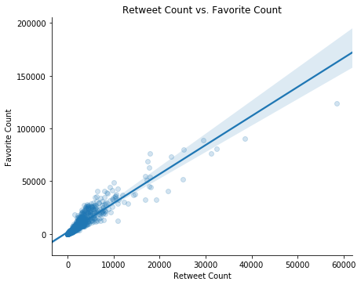

```python
#scatterplot of retweet count vs. favorite count
sns.lmplot(x="retweet_count", y="favorite_count", data=twitter, size = 5, aspect = 1.3, scatter_kws={'alpha':1/5})
plt.title('Retweet Count vs. Favorite Count')
plt.xlabel('Retweet Count')
plt.ylabel('Favorite Count');
```

Majority of the data commence below 35,000 favorites and below 10,000 retweets. Both counts are highly positively correlated. The most dog tweets had more favorites than retweets. This is more likely expectation since more people will favorite instead of taking ownership of the retweet. I noticed this in many Twitter account profile says, “My tweets are my own” so, they don’t retweet.

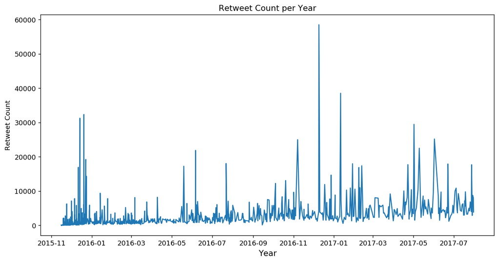

```python
#sum up all favorite count of a particular year
retweet_per_year = twitter.groupby('timestamp')['retweet_count'].sum()

#figure size(widht, height)
plt.figure(figsize=(12,6), dpi = 130)

#x axis
plt.xlabel('Year', fontsize = 12)
#y axis
plt.ylabel('Retweet Count')
#title
plt.title('Retweet Count per Year', fontsize = 12)
# plot graph
plt.plot(retweet_per_year)

#display the plot
plt.show()
```

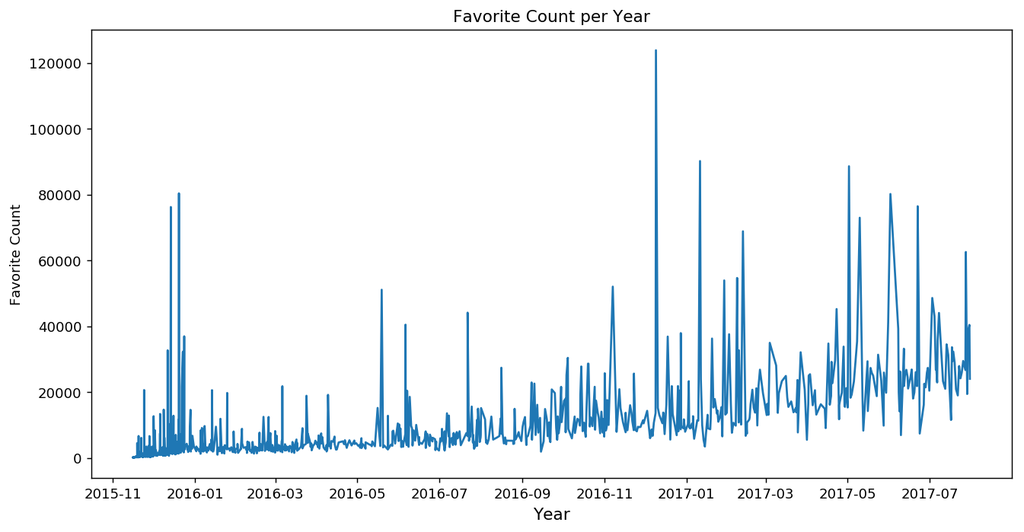

```python
#sum up all favorite count of a particular year
favorite_per_year = twitter.groupby('timestamp')['favorite_count'].sum()

#figure size(widht, height)
plt.figure(figsize=(12,6), dpi = 130)

#x axis
plt.xlabel('Year', fontsize = 12)
#y axis
plt.ylabel('Favorite Count')
#title
plt.title('Favorite Count per Year', fontsize = 12)
# plot graph
plt.plot(favorite_per_year)

#display the plot
plt.show()
```

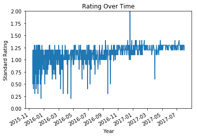

```python
twitter.groupby('timestamp')['rating'].mean().plot(kind='line')
plt.ylim(0, 2)
plt.title('Rating Over Time')
plt.xlabel('Year')
plt.ylabel('Standard Rating')
plt.show;
```

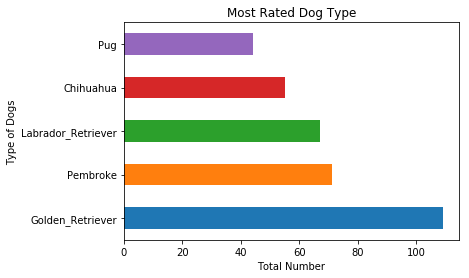

```python
twitter_dog_type = twitter.groupby('dog_type').filter(lambda x: len(x) >= 30)

twitter_dog_type['dog_type'].value_counts().plot(kind = 'barh')
plt.title('Most Rated Dog Type')
plt.xlabel('Total Number')
plt.ylabel('Type of Dogs')

fig = plt.gcf()
fig.savefig('output.png', bbox_inches='tight');
```

Golden retriever is the number one most rated dog type. Pembroke as second, and third is Labrador retriever.

**Resources**

https://www.quora.com/What-does-t-do-in-Python

https://www.pythoncentral.io/introduction-to-tweepy-twitter-for-python

https://stackoverflow.com/questions/47334968/pandas-keyerror-value-not-in-index

https://stackoverflow.com/questions/23668427/pandas-three-way-joining-multiple-dataframes-on-columns

https://developer.twitter.com/en/docs/ads/creatives/api-reference/tweets.html

https://stackoverflow.com/questions/47612822/how-to-create-pandas-dataframe-from-twitter-search-api

https://docs.oracle.com/en/cloud/paas/integration-cloud-service/icstw/getting-invalid-or-expired-token-error-response.html

https://stackoverflow.com/questions/13635215/convert-a-string-such-that-the-first-letter-is-uppercase-and-everythingelse-is-l

https://stackoverflow.com/questions/32364127/store-function-result-into-variable

https://www.geeksforgeeks.org/apply-uppercase-to-a-column-in-pandas-dataframe/